# A Homework of Biblical Proportions

Sanath Shivaswamy & Christian Ghorbani

April 29, 2016

In this HW, which I borrowed from Professor Mahmoud Parsian’s course on Big Data (highly recommended), we will analyze the text of the bible. The ascii version resides in the file “ascii_bible.txt” on Camino. Use an editor to familiarize yourself with the structure of the file. Then perform the following operations, listed below as questions for you to answer.

## Q1: Read in the file using any R function you like and store each verse in a text array. After which print the top 20 verses. (Remove the top two lines which contain the title.)

```r
library(stringr)
```

```r
bible_full = readLines("ascii_bible.txt")
bible_text = str_replace(bible_full,"^\\s+","") #remove leading whitespaces
res = grep("[0-9][0-9][0-9]:[0-9][0-9][0-9]",bible_text)
temp = NULL
for (i in seq(1:(length(res)-1))){
  x = paste(bible_text[res[i]:(res[i+1]-1)],collapse = " ")
  temp = c(temp,x)
}
verses = c(temp,paste(bible_text[res[length(res)]:length(bible_text)],collapse = " "))
verses[1:20]
```

```
##  [1] "001:001 In the beginning God created the heaven and the earth. "
##  [2] "001:002 And the earth was without form, and void; and darkness was upon the face of the deep. And the Spirit of God moved upon the face of the waters. "
##  [3] "001:003 And God said, Let there be light: and there was light. "
##  [4] "001:004 And God saw the light, that it was good: and God divided the light from the darkness. "
##  [5] "001:005 And God called the light Day, and the darkness he called Night. And the evening and the morning were the first day. "
##  [6] "001:006 And God said, Let there be a firmament in the midst of the waters, and let it divide the waters from the waters. "
##  [7] "001:007 And God made the firmament, and divided the waters which were under the firmament from the waters which were above the firmament: and it was so. "
##  [8] "001:008 And God called the firmament Heaven. And the evening and the morning were the second day. "
##  [9] "001:009 And God said, Let the waters under the heaven be gathered together unto one place, and let the dry land appear: and it was so. "
## [10] "001:010 And God called the dry land Earth; and the gathering together of the waters called he Seas: and God saw that it was good. "
## [11] "001:011 And God said, Let the earth bring forth grass, the herb yielding seed, and the fruit tree yielding fruit after his kind, whose seed is in itself, upon the earth: and it was so. "
## [12] "001:012 And the earth brought forth grass, and herb yielding seed after his kind, and the tree yielding fruit, whose seed was in itself, after his kind: and God saw that it was good. "
## [13] "001:013 And the evening and the morning were the third day. "
## [14] "001:014 And God said, Let there be lights in the firmament of the heaven to divide the day from the night; and let them be for signs, and for seasons, and for days, and years: "
## [15] "001:015 And let them be for lights in the firmament of the heaven to give light upon the earth: and it was so. "
## [16] "001:016 And God made two great lights; the greater light to rule the day, and the lesser light to rule the night: he made the stars also. "
## [17] "001:017 And God set them in the firmament of the heaven to give light upon the earth, "
## [18] "001:018 And to rule over the day and over the night, and to divide the light from the darkness: and God saw that it was good. "
## [19] "001:019 And the evening and the morning were the fourth day. "
## [20] "001:020 And God said, Let the waters bring forth abundantly the moving creature that hath life, and fowl that may fly above the earth in the open firmament of heaven. "
```

## Q2: How many verses are there in total?

```r
length(verses)
```

```
## [1] 31102
```

```r
# 31102 verses in bible
```

## Q3: Each verse has the number “CCC:VVV” where CCC is the chapter number and VVV is the verse number. How many chapters are there?

```r
chap = grep("[0-9][0-9][0-9]:001",verses)
length(chap)
```

```
## [1] 1189
```

```r
# 1189 Chapters in bible
```

## Q4: Extract an array for the verse numbers, and also one for the verse text.

```r
ver_no = c(substr(verses,5,7)) #array of verse numbers
ver_txt =  str_split_fixed(verses, "[0-9][0-9][0-9]:[0-9][0-9][0-9] ",2)
ver_txt = ver_txt[,2]
head(ver_no)
```

```
## [1] "001" "002" "003" "004" "005" "006"
```

```r
head(ver_txt)
```

```
## [1] "In the beginning God created the heaven and the earth. "
## [2] "And the earth was without form, and void; and darkness was upon the face of the deep. And the Spirit of God moved upon the face of the waters. "
## [3] "And God said, Let there be light: and there was light. "
## [4] "And God saw the light, that it was good: and God divided the light from the darkness. "
## [5] "And God called the light Day, and the darkness he called Night. And the evening and the morning were the first day. "
## [6] "And God said, Let there be a firmament in the midst of the waters, and let it divide the waters from the waters. "
```

## Q5: Lower case all text.

```r
ver_txt = str_to_lower(ver_txt)
```

## Q6: Convert the text of all verses into a Corpus using the **tm** package.

```r
library(tm)
ver_txt = Corpus(VectorSource(ver_txt))
ver_txt
```

```
## <<VCorpus>>
## Metadata:  corpus specific: 0, document level (indexed): 0
## Content:  documents: 31102
```

## Q7: Remove all punctuation. Use a corpus function for this. How many unique words are there?

```r
ver_txt = tm_map(ver_txt,removePunctuation)
ver_uniq = DocumentTermMatrix(ver_txt)
ver_uniq
```

```
## <<DocumentTermMatrix (documents: 31102, terms: 12651)>>
## Non-/sparse entries: 510124/392961278
## Sparsity           : 100%
## Maximal term length: 18
## Weighting          : term frequency (tf)
```

```r
#12651 unique words
```

## Q8: Remove all stopwords. Now how many unique terms are there?

```r
ver_stp = ver_txt
ver_stp = tm_map(ver_stp,removeWords,stopwords("english"))
ver_uniq = DocumentTermMatrix(ver_stp)
ver_uniq
```

```
## <<DocumentTermMatrix (documents: 31102, terms: 12555)>>
## Non-/sparse entries: 336052/390149558
## Sparsity           : 100%
## Maximal term length: 18
## Weighting          : term frequency (tf)
```

```r
#12555 unqiue words
```

## Q9: Now stem the text, and see how many unique words there are.

```r
library(SnowballC)
ver_stem = tm_map(ver_stp,stemDocument)
ver_uniq = DocumentTermMatrix(ver_stem)
ver_uniq
```

```
## <<DocumentTermMatrix (documents: 31102, terms: 9125)>>
## Non-/sparse entries: 332862/283472888
## Sparsity           : 100%
## Maximal term length: 18
## Weighting          : term frequency (tf)
```

```r
#9125 unique words
```

## Q10: Convert the corpus into a term-document matrix (TDM), where each verse is a separate document. How many distinct words are there in the bible?

```r
ver_tdm = DocumentTermMatrix(ver_stem)
ver_tdm
```

```
## <<DocumentTermMatrix (documents: 31102, terms: 9125)>>
## Non-/sparse entries: 332862/283472888
## Sparsity           : 100%
## Maximal term length: 18
## Weighting          : term frequency (tf)
```

```r
#9125 distinct words in the bible
```

## Q11: Convert the TDM into a matrix and find the 50 most common words in the bible.

```r
spr_rmv = removeSparseTerms(ver_tdm,0.99)
ver_mat = as.matrix(spr_rmv)
cm_words = sort(colSums(ver_mat), decreasing = TRUE) #frequency for each term
w_50 = head(cm_words,50)
w_50 #50 most common words
```

```
##    shall     unto     lord     thou      god      thi     said     will
##     9838     8997     8007     5474     4727     4600     3999     3893
##     thee      son     king     upon      man      day   israel      say
##     3826     3486     2877     2748     2735     2611     2575     2532
##     hath     hous    peopl     came     come      one     hand children
##     2264     2160     2145     2093     2088     2046     1943     1821
##     also     land    thing      men   father    shalt      let     even
##     1769     1767     1704     1677     1675     1616     1512     1454
##     made     went    offer      now   behold     citi    saith     word
##     1405     1400     1368     1356     1341     1316     1262     1245
## therefor    everi     hast     name     make    great    david      may
##     1237     1236     1150     1135     1086     1081     1064     1027
##     pass    earth
##     1004      992
```

## Q12: Make a wordcloud of the top 100 words in the bible.

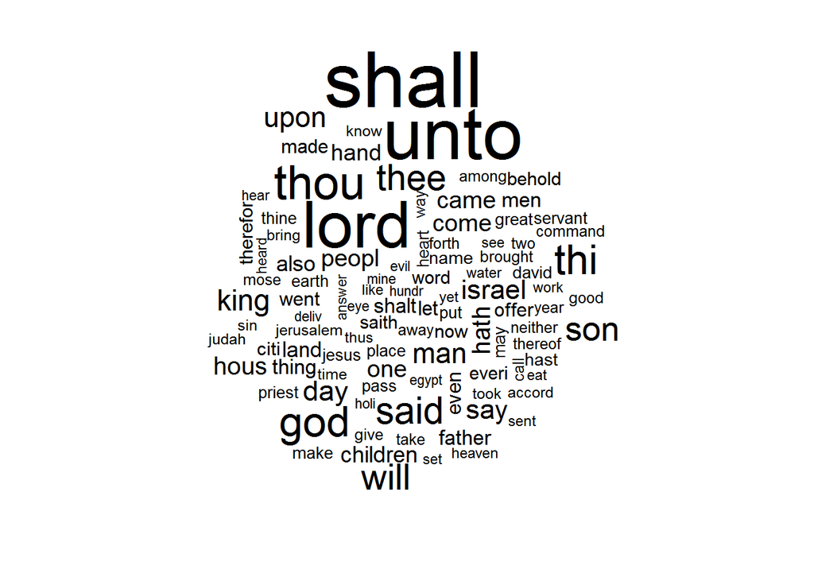

```r
library(wordcloud)
w_100 = head(cm_words,100)
w_100_nms = names(w_100) #names of top 100 words
wordcloud(w_100_nms,w_100) #creating word cloud
```

## Q13: Mood score the original text of the bible (before stemming)

```r
#creating positive and negitive words
HIDict = readLines("inqdict.txt")
dict_pos = HIDict[grep("Pos",HIDict)]
poswords = NULL
for (s in dict_pos) {
    s = strsplit(s,"#")[[1]][1]
    poswords = c(poswords,strsplit(s," ")[[1]][1])
}
dict_neg = HIDict[grep("Neg",HIDict)]
negwords = NULL
for (s in dict_neg) {
    s = strsplit(s,"#")[[1]][1]
    negwords = c(negwords,strsplit(s," ")[[1]][1])
}
poswords = tolower(poswords)
negwords = tolower(negwords)
poswords = unique(poswords)
negwords = unique(negwords)

#Mood Scoring the bible text
ver_txt =  str_split_fixed(verses, "[0-9][0-9][0-9]:[0-9][0-9][0-9] ",2)
ver_txt = ver_txt[,2] #bible text
ver_txt = Corpus(VectorSource(ver_txt))
ver_txt = tm_map(ver_txt,removePunctuation)
v1 = data.frame(text = sapply(ver_txt, as.character), stringsAsFactors = FALSE) #corpus to dataframe
v1 = str_replace(v1$text,"^\\s+","")  #remove leading whitespaces
v1 = trimws(v1,which = "right") # triming trailing whitespaces
v1 = str_to_lower(v1)
ver_txt1 = unlist(strsplit(v1," ")) #spliting by space to get words
posmatch = match(ver_txt1,poswords)
numposmatch = length(posmatch[which(posmatch>0)])
negmatch = match(ver_txt1,negwords)
numnegmatch = length(negmatch[which(negmatch>0)])
print(c(numposmatch,numnegmatch))
```

```
## [1] 56827 38769
```

```r
#No of Positive words = 56827
#No of Negative words = 38769
```

## Q14: Summarize the bible into 100 verses. (Or some fraction of the total number of verses, it’s your choice.) Be super careful here as this may take a long time unless you are clever about it, or find some elegant way to speed things up!

```r
a = c(2,2)
b = c(2,2)
x = data.frame(a,b)
y = data.frame(a,b)
z = data.frame(a,b)
column_names = c("Pos_Score","Verse")
x = `colnames<-`(x,column_names)
counter = 1
for(verse in v1){
  ver_txt1 = unlist(strsplit(verse," "))
  posmatch = match(ver_txt1,poswords)
  numposmatch = length(posmatch[which(posmatch>0)])
  if(numposmatch > 5){ #taking only those verses which have positive mood score > 5
    x[counter,1] = numposmatch
    x[counter,2] = verse
    counter = counter + 1
  }
}

sum_txt = x$Verse #Taking only verses

#Function to generate Summary
text_summary = function(text, n) {
  m = length(text)  # No of sentences in input
  jaccard = matrix(0,m,m)  #Store match index
  for (i in 1:m) {
    for (j in i:m) {
      a = text[i]; aa = unlist(strsplit(a," "))
      b = text[j]; bb = unlist(strsplit(b," "))
      jaccard[i,j] = length(intersect(aa,bb))/
                          length(union(aa,bb))
      jaccard[j,i] = jaccard[i,j]
    }
  }
  similarity_score = rowSums(jaccard)
  res = sort(similarity_score, index.return=TRUE,
          decreasing=TRUE)
  idx = res$ix[1:n]
  summary = text[idx]
}

#Summary of bible with 100 verses
res = text_summary(sum_txt,100)
res
```

```
##   [1] "for this is the covenant that i will make with the house of israel after those days saith the lord i will put my laws into their mind and write them in their hearts and i will be to them a god and they shall be to me a people"
##   [2] "and i will give them an heart to know me that i am the lord and they shall be my people and i will be their god for they shall return unto me with their whole heart"
##   [3] "and their nobles shall be of themselves and their governor shall proceed from the midst of them and i will cause him to draw near and he shall approach unto me for who is this that engaged his heart to approach unto me saith the lord"
##   [4] "and the lord said unto moses go in unto pharaoh for i have hardened his heart and the heart of his servants that i might shew these my signs before him"
##   [5] "your kerchiefs also will i tear and deliver my people out of your hand and they shall be no more in your hand to be hunted and ye shall know that i am the lord"
##   [6] "and i will sow her unto me in the earth and i will have mercy upon her that had not obtained mercy and i will say to them which were not my people thou art my people and they shall say thou art my god"
##   [7] "and he saith unto them ye shall drink indeed of my cup and be baptized with the baptism that i am baptized with but to sit on my right hand and on my left is not mine to give but it shall be given to them for whom it is prepared of my father"
##   [8] "and it shall come to pass while my glory passeth by that i will put thee in a clift of the rock and will cover thee with my hand while i pass by"
##   [9] "and it shall be said in that day lo this is our god we have waited for him and he will save us this is the lord we have waited for him we will be glad and rejoice in his salvation"
##  [10] "and i will sanctify my great name which was profaned among the heathen which ye have profaned in the midst of them and the heathen shall know that i am the lord saith the lord god when i shall be sanctified in you before their eyes"
##  [11] "but this shall be the covenant that i will make with the house of israel after those days saith the lord i will put my law in their inward parts and write it in their hearts and will be their god and they shall be my people"
##  [12] "speak unto aaron and to his sons and unto all the children of israel and say unto them whatsoever he be of the house of israel or of the strangers in israel that will offer his oblation for all his vows and for all his freewill offerings which they will offer unto the lord for a burnt offe…
##  [13] "wherefore in all things it behoved him to be made like unto his brethren that he might be a merciful and faithful high priest in things pertaining to god to make reconciliation for the sins of the people"
##  [14] "now therefore call unto me all the prophets of baal all his servants and all his priests let none be wanting for i have a great sacrifice to do to baal whosoever shall be wanting he shall not live but jehu did it in subtilty to the intent that he might destroy the worshippers of baal"
##  [15] "say unto them as i live saith the lord god i have no pleasure in the death of the wicked but that the wicked turn from his way and live turn ye turn ye from your evil ways for why will ye die o house of israel"
```

[output cut: 85 more lines]

```r
#Working code to produce a Negative Summary
#a = c(2,2)
#b = c(2,2)
#x = data.frame(a,b)
#y = data.frame(a,b)
#z = data.frame(a,b)
#column_names = c("Neg_Score","Verse")
#x = `colnames<-`(x,column_names)
#counter = 1
#for(verse in v1){
#  ver_txt1 = unlist(strsplit(verse," "))
#  negmatch = match(ver_txt1,negwords)
#  numnegmatch = length(negmatch[which(negmatch>0)])
#  if(numnegmatch > 5){ #taking only those verses which have positive mood score > 5
#    x[counter,1] = numnegmatch
#    x[counter,2] = verse
#    counter = counter + 1
#  }
#}

#sum_txt = x$Verse

#res = text_summary(sum_txt,100)
#head(res)
```

```r
#Working code to produce a Mix of Positive and Negative Summary
#a = c(2,2)
#b = c(2,2)
#x = data.frame(a,b)
#y = data.frame(a,b)
#z = data.frame(a,b)
#column_names = c("Verse")
#x = `colnames<-`(x,column_names)
#counter = 1
#for(verse in v1){
#  ver_txt1 = unlist(strsplit(verse," "))
#  posmatch = match(ver_txt1,poswords)
#  numposmatch = length(posmatch[which(posmatch>0)])
#  negmatch = match(ver_txt1,negwords)
#  numnegmatch = length(negmatch[which(negmatch>0)])
#  if(numposmatch > 5 | numnegmatch > 5){ #taking only those verses which have positive mood score > 5
#    x[counter,1] = verse
#    counter = counter + 1
#  }
#}
#sum_txt = x$Verse

#Summary of bible with 100 verses
#res = text_summary(sum_txt,100)
#head(res)
```